# Probability Distributions: Binomial

## What is a probability distribution?

For a given variable (e.g., house prices), the frequency of ranges of this variable (i.e., classes, groups, intervals).

### Discrete or continuous?

- Discrete: the number of distinct events (integers)
- Continuous: always possible to find a number between any two events (real number)

### Examples of distributions

1. The **Bernoulli** distribution is used in situations where an uncertain parameter can take on one of only two possible values.
2. The **binomial** distribution is used for the number of outcomes on repeated trials when each trial is independently sampled (with replacement).
3. The **hypergeometric** distribution is used for the number of outcomes on repeated trials when each trial is dependent on another trial (without replacement).
4. The **poisson** distribution is used for the number of outcomes in a unit of time.
5. The **uniform** distribution describes an outcome that is equally likely to fall anywhere between a minimum and a maximum value.
6. The **triangular** distribution is a more flexible family of continuous distributions: these distributions are specified by three parameters: the minimum, maximum, and most likely values.
7. The **normal** distribution is a symmetric distribution, usually specified by its mean and standard deviation.
8. The **exponential** distribution describes the frequency of times elapsed between random poisson occurrences.

## Being binomial

### Consumer goods ‘r’ us

From a Consumer Food database.

1. What proportion of the database households are in the Metro area? Use this as the value of $p$ in a binomial distribution.
2. If you were to randomly select 25 of these households, what is the probability that exactly 8 would be in the Metro area?
3. If you were to randomly select 12 of these households, what is the probability that 3 or fewer would be households in the Metro area?

### What’s a binomial?

- Two possible event outcomes only in each run or scenario of a binomial process
- E.g., default/not-default, reject/accept, comply/not-comply events
- Let $x$ = comply, then $P(x)$ = probability of compliance and $1 - P(x)$ = probability of non-compliance.

Three assumptions:

1. Each replication of the process is a **combination** of events that results in one of two possible outcomes (usually referred to as “success”" or “failure” events).
2. The probability of success is the same for each replication.
3. The replications are independent, meaning here that a success in one replication does not influence the probability of success in another.

## What’s a combination?

Start with a set of choices or categories. Combinations are the complete set of different ways you can arrange the various subsets of choices or categories.

### For a simple example

- Start with the set of $A= \{1,2\}$, where “1” is “comply” and “2” is “don’t comply.”
- You can form four subsets of this set: {}, {1}, {2}, and {1,2} (don’t forget the *null* or “do nothing” subset). These subsets are the **combinations** of set A.
- Order does not matter so that $\{1,2\}$ is the same as $\{2,1\}$

## We have to start with permutation first

A permutation does care about the order of the elements in a subset, much like the order of letter in a word. We will find that combinations are found from permutations.

### Start with $A = \{a,b,c,d,e\}$ letters in a text to your friend.

- With 5 letters to choose from we can select the first letter in 5 ways.
- We now have 4 letters left, so the second letter can be chosen in 4 ways,
- Then the third letter in 3 ways
- The fourth letter in 2 ways
- The fifth letter in 1 way or
  $$5! = 5 \times 4 \times 3 \times 2 \times 1 = 120$$
  ways to build a word of text (granted some of these might be code).

### Find the number of 3 letter words you can form from a list of 5 letters.

Using the same logic as above this is
$$5 \times 4 \times 3 = 60$$
There are 120 possible words you can form from 5 letters. There are 60 possible 3 letter sequences. This is called a **permutation**. In symbols we have 5 *permute* 3 or $_{5}P_{3}$. We notice that $5! = 5 \times 4 \times 3 \times 2 \times 1 = 5 \times 4 \times 3 \times 2!$. So all we need to do to get the 60 permutations is take 5! and divide by 2! to get

$$_{5}P_{3} = \frac{5!}{2!} = 60$$

Generally we have for $n$ elements permuted $x$ at a time:

$$_{n}P_{x} = \frac{n!}{(n-x)!}$$

### What about combinations?

Now we don’t care about the order of the letters. We seem to also know that

- **Permutations** track with the order of elements, here, letters: {a,d,c} $\neq$ {d,c,a}
- **Combinations** don’t worry about the order of elements: {a,d,c} = {d,c,a}
- Thus out of the 60 permutations we just counted, we have to keep only one in $3 \times 2 \times 1 = 3! = 6$ (1/6th) of the 60 Permutations or 10 combinations. We then have 6 times more permutations than we need to account for combinations.

## Combinations from permutations

For our 5 letters taken 3 at a time without regard to the order of letters, we have
$$_{5}C_{3} = {5 \choose 3} = \frac{5!}{3! \, (5 - 3)!}$$
and then we compute
$$= \frac{5x4x3x2x1}{(3x2x1)(2x1)} = 10$$
More generally, we have
$$_{n}C_{x} = {n \choose x} = \frac{n!}{x! \, (n - x)!}$$
and
$$_{n}P_{x} = _{n}C_{x}x! = {n \choose x}x! = \frac{n!}{(n - x)!}$$

## Try these: combinations and permutations

A risk management practice has 8 members. Teams of three are formed to work with client project teams and provide management, subject matter expertise and budget and scheduling control. The practice leader wants to know

1. How many different project teams (“teams”) can be formed from the practice?
2. How many teams of 3 members can be formed from the practice if each team is to have a team manager, a project controller, and a subject matter expert?

### Results: combinations and permutations

1. How many different project teams (“teams”) can be formed from the practice?

We will find the number of *combinations* of 8 members taken 3 at a time without regard for the order. Calculate
$$_{8}C_{3} = {8 \choose 3} = \frac{8!}{3! \, (8 - 3)!}$$
so that
$$_{8}C_{3} = \frac{8x7x6x5x4x3x2x1}{(3x2x1)(5x4x3x2x1)} = \frac{336}{6} = 56$$
potential combinations of practice members.

2. How many teams of 3 members can be formed from the practice if each team is to have a team manager, a project controller, and a subject matter expert?

The practice leader is now interested in finding the number of *permutations* of 8 members taken 3 at a time, *when the order matters*. Calculate
$$_{8}P_{3} = {8 \choose 3}3! = \frac{8!}{3! \, (8 - 3)!}3!$$
so that
$$= 56 \, (3x2x1) = 336$$
potential permutations of practice members.

## So how do we use the binomial process?

Follow these steps:

1. How many times did we repeat the process (number of observations)? $n$.
2. How many successes (events we are tracking)? $x$
3. How often does a success occur (event we are tracking)? $p(X = x)$
4. How many $x$ successes (events) in $n$ replications (trials, observations)? The number of possible combinations of $x$ successes in $n$ replications is
   $$_{n}C_{x} = {n \choose x} = \frac{n!}{x! \, (n - x)!}$$
   The $x$ successes can occur anywhere among the $n$ trials (observations). There are $_{n}C_{x}$ different ways of distributing $x$ successes in a sequence of $n$ trials (observations).
5. What is the probability of a single scenario (combination = 1) of $x$ successes? $p^x$
6. What is the probability of a single scenario of $n-x$ failures? $(1-p)^{n-x}$
7. What is the probability of all combinations of $x$ successes in $n$ trials (using the Excel formula)?
   $$P(X = x \mid n, p) = {n \choose x}p^x (1-p)^{n-x}$$
   We can also use the $BINOM.DIST(x,n,p,FALSE)$ formula in Excel, where `FALSE` indicates that we calculate the probability mass function value (the relative frequency) and `TRUE` indicates that we calculate cumulative probability value (the cumulative relative frequency).

## Try this: binomial distribution

A environmental control specialist picks a sample of 10 sensors from a large shipment of sensors. Experience has shown that 1 in 5 sensors fail to work when installed. The specialist is scheduling her time for the week and wants to know

1. What is the probability that she will pick exactly 2 of the defective sensors?
2. What is the probability that she will pick no more than 2 of the defective sensors?

### Results: binomial distribution

1. What is the probability that she will pick exactly 2 of the defective sensors?

Follow these steps:

1. How many times did we repeat the process (number of observations)? Here $10$ is the sample size.
2. How many successes (we are tracking “defective” sensors)? No more than $2$ defective sensors.
3. How often does a success (“defective” sensor) occur (event we are tracking)? $p = 1/5 = 0.20$.
4. How many $x$ successes (events) in $n$ replications (trials, observations)? The number of possible combinations of $2$ successes (“defective” sensors) in $10$ replications (sample size) is
   $$_{10}C_{2} = {10 \choose 2} = \frac{10 !}{2! \, (10 - 2)!} = 45$$

The $2$ defective sensors can occur anywhere among the $10$ sampled sensors. There are $_{10}C_{2}$ different ways of distributing $2$ defective sensors in a sequence of $10$ sampled sensors (observations).

5. What is the probability of a single scenario (combination = 1) of $x$ successes? $(0.2)^2 = 0.04$.
6. What is the probability of a single scenario of $n-x$ failures? $(1-0.2)^{10-2} = (0.8)^8 = 0.1678$
7. What is the probability of all combinations of $2$ defective sensors in a sample of $10$ sensors?
   $$Binom(10,2,0.2) = {10 \choose 2}(0.2)^2 (1-0.2)^{10-2}$$
   or
   $$Binom(10,2,0.2) = (45)(0.04)(0.1678) = 0.3020$$
   and in Excel `BINOM.DIST(2,10,0.2,FALSE)`.
8. What is the probability that she will pick no more than 2 of the defective sensors?

Assuming no intersections and independent sampling of the 10 sensors,the probability is the union of three events, finding 0, 1, and 2 defective sensors. We have
$$P(X \leq 2) = P(X = 0) + P(X = 1) + P(X = 2)$$
We already have $P(X = 2) = 0.3020$. Now we calculate

$$P(X = 0) = Binom(10,0,0.2) = {10 \choose 0}(0.2)^0 (1-0.2)^{10-0}$$
or
$$Binom(10,0,0.2) = 0.1074$$
Similarly,$P(X = 1) = 0.2684$. We have then
$$P(X \leq 2) = P(X = 0) + P(X = 1) + P(X = 2) = 0.6778$$

## Try another

Using the same sensor problem, what is the probability that she will pick 8 or more defective sensors? What if she picks more than 8 defective sensors?

- Build a simple spreadsheet table to answer these questions.

### Result

Assuming no intersections and independent sampling of the 10 sensors,the probability is the union of three events, finding 8, 9, and 10 defective sensors. We have, if she finds 8 or more defective sensors,
$$P(X \geq 8) = P(\{X=8\}\cup \{X=9\} \cup \{X=10\})$$
and with mutually exclusive, independent (with replacement) events,
$$P(\{X=8\}\cup \{X=9\} \cup \{X=10\})$$
$$= P(X = 8) + P(X = 9) + P(X = 10) = 0.0078\%$$
Finding more than 8 sensors
$$P(X > 8) = P(\{X=9\} \cup \{X=10\})$$
and with mutually exclusive, independent (with replacement) events,
$$P(\{X=9\} \cup \{X=10\}) = P(X = 9) + P(X = 10) = 0.00042\%$$

Here is a worksheet table that builds up these calculations.

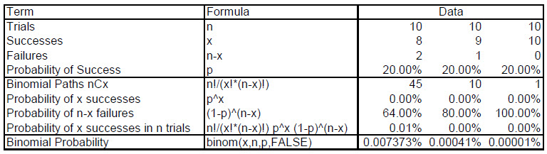

## What does a graph of the binomial look like?

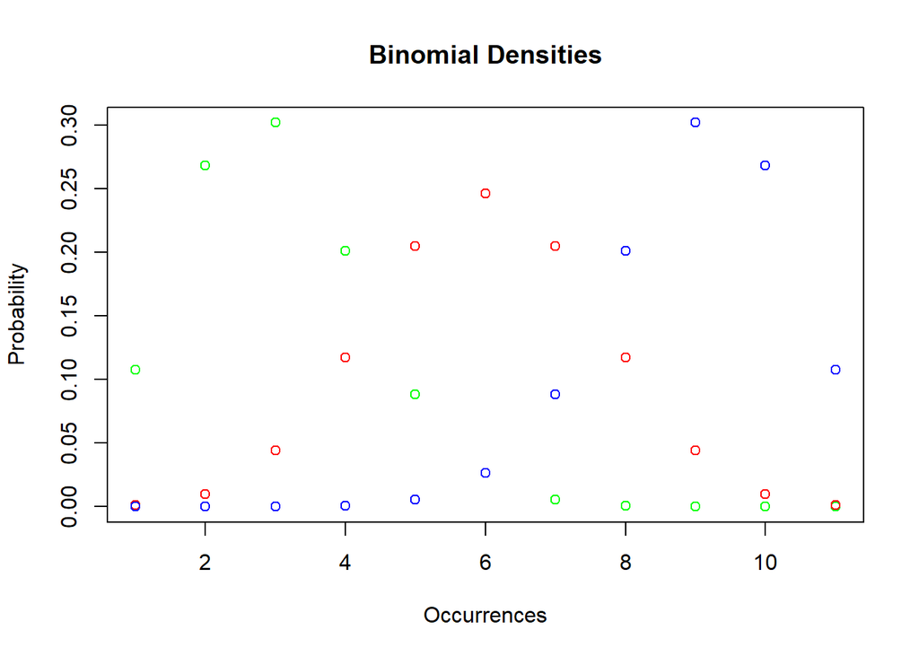

## Binomial statistics

- Mean of a binomial distribution
  $$\mu = n p$$
- Standard deviation of a binomial distribution
  $$\sigma = (n p (1-p))^{1/2}$$

## Try this

What are the mean and standard deviation of the sensor problem above?

### Result

We calculate for $n = 10$ and $p = 0.20$

Mean of the sensor binomial distribution
$$\mu = n p = (10)(0.20) = 2$$
defective sensors.

Standard deviation of the sensor binomial distribution
$$\sigma = (n p (1-p))^{1/2} = ((10)(0.20)(0.80))$$
1.26, or rounding down, 1 defective sensor.

## Short exercises

1. Hospital records show that of patients suffering from a certain rare disease, 75% die of it. What is the probability that of 6 randomly selected patients, 4 will recover?

*Answer*: 3.3%

2. For the patients suffering from a certain disease, What is the probability that all 6 randomly selected patients will recover?

*Answer*: very, very small

3. You are trying reach your surveying team in the iron rich creases of the Mesabi mountain range. there was a probability of 80% of success in any attempt to connect by cell phone. What is the probability of having 7 successes in 10 attempts?

*Answer*: a little over 20%

4. A manufacturer of metal pistons finds that, on the average, 12% of the pistons are rejected by customers because they are either oversize or undersize. What is the probability that a batch of 10 pistons will contain no more than 2 rejects?

*Answer*: 89%